# Predicting Airline Delays

Pavan Keerthi

Thursday, Apr 10, 2015

**SYNOPSIS :** Implements a Logistic Regression Model on airline delays dataset

**DESCRIPTION :** The data used is from the below link.We use 2007 data to predict Departure delays for flights originating from JFK Airport

*Ref Links :* http://stat-computing.org/dataexpo/2009/the-data.html

*Version History*  
v0.1 - 16-Apr-2015 - Pavan Keerthi - Initial Version

### Setup

We make use of following libraries for this program

**Hmisc :** Its cut2 function  
**dplyr :** Its the most handy i find to work with data frames .Especially its select/filter/mutate functions are used extensively here  
**stringr :** To manuplate string data types  
**reshape2 :** To pivot/unpivot the dataframe as requried  
**glm2 :** Machine Learning library to implement Logistic regression.It has few options which might be useful  
**ggplot2 :** The best plotting library in R

```r
# Load required libraries.
# Here order is important since these packages mask common functions
library(Hmisc)
library(dplyr)
library(stringr)
library(reshape2)
library(ggplot2)
library(glm2)
```

Lets set working directory  
*Note:* Change this to your local path

```r
setwd("C:\\Users\\Pavan\\Work\\DataScience-Examples\\Predicting_Airline_Delays\\R Implementation")
```

Lets load the file as dataframe into memory  
Its a quite a big file (670MB) so it may take few mins

### Acquire data

```r
# Load CSV data
data<-read.csv("C:\\Users\\Pavan\\Work\\DataScience-Examples\\_data\\airlinedelays\\2007.csv",header=TRUE,sep=",",na.strings = "NA",stringsAsFactors =TRUE)
```

We will focus only on building Delay prediction model only for flights departing from **JFK** airport

```r
# filter data frame to include only flight originating from JFK
data <-filter(data,Origin =='JFK')
```

### Explore & Transform data

Lets read the structure of data frame to get familiar with it

```r
# Read Structure
str(data)
```

```
## 'data.frame':    126366 obs. of  29 variables:
##  $ Year             : int  2007 2007 2007 2007 2007 2007 2007 2007 2007 2007 ...
##  $ Month            : int  1 1 1 1 1 1 1 1 1 1 ...
##  $ DayofMonth       : int  13 1 15 5 3 30 2 18 19 4 ...
##  $ DayOfWeek        : int  6 1 1 5 3 2 2 4 5 4 ...
##  $ DepTime          : int  1416 2035 1949 1915 1747 1748 1750 1850 1750 1745 ...
##  $ CRSDepTime       : int  1435 1750 1750 1750 1750 1750 1750 1750 1750 1750 ...
##  $ ArrTime          : int  1608 2223 2205 2159 1930 2000 1957 2108 2019 2001 ...
##  $ CRSArrTime       : int  1621 1955 1955 1955 1955 1955 1955 1955 1955 1955 ...
##  $ UniqueCarrier    : Factor w/ 20 levels "9E","AA","AQ",..: 19 19 19 19 19 19 19 19 19 19 ...
##  $ FlightNum        : int  2290 2290 2290 2290 2290 2290 2290 2290 2290 2290 ...
##  $ TailNum          : Factor w/ 5506 levels "","0","000000",..: 665 560 560 558 434 558 558 1129 1130 435 ...
##  $ ActualElapsedTime: int  112 108 136 164 103 132 127 138 149 136 ...
##  $ CRSElapsedTime   : int  106 125 125 125 125 125 125 125 125 125 ...
##  $ AirTime          : int  82 67 78 68 74 94 74 96 88 74 ...
##  $ ArrDelay         : int  -13 148 130 124 -25 5 2 73 24 6 ...
##  $ DepDelay         : int  -19 165 119 85 -3 -2 0 60 0 -5 ...
##  $ Origin           : Factor w/ 304 levels "ABE","ABI","ABQ",..: 153 153 153 153 153 153 153 153 153 153 ...
##  $ Dest             : Factor w/ 310 levels "ABE","ABI","ABQ",..: 64 64 64 64 64 64 64 64 64 64 ...
##  $ Distance         : int  425 425 425 425 425 425 425 425 425 425 ...
##  $ TaxiIn           : int  6 8 7 5 6 12 9 8 6 28 ...
##  $ TaxiOut          : int  24 33 51 91 23 26 44 34 55 34 ...
##  $ Cancelled        : int  0 0 0 0 0 0 0 0 0 0 ...
##  $ CancellationCode : Factor w/ 5 levels "","A","B","C",..: 1 1 1 1 1 1 1 1 1 1 ...
##  $ Diverted         : int  0 0 0 0 0 0 0 0 0 0 ...
##  $ CarrierDelay     : int  0 9 0 0 0 0 0 0 0 0 ...
##  $ WeatherDelay     : int  0 0 0 0 0 0 0 0 0 0 ...
##  $ NASDelay         : int  0 0 11 39 0 0 0 13 24 0 ...
##  $ SecurityDelay    : int  0 0 0 0 0 0 0 0 0 0 ...
##  $ LateAircraftDelay: int  0 139 119 85 0 0 0 60 0 0 ...
```

First line from the output tells us that this dataset has 126366 rows and 29 columns The next lines give detail output and sample values of each column.We have int’s and Factors (Strings were converted to Factors which is more effecient data structure )

We also notice that there are some columns like *FlightNum* which is of integer data type.Its quite meaningless in this context so lets convert those too to factors

```r
## Convert FlightNum
data$Der_FlightNum<- as.factor(data$FlightNum)
```

We also have some columns like *cancelled,diverted, day,weeknum* as integer which would be more effiecient as Factors.So lets conver them too

```r
# convert Cancelled,Diverted columns
data$Der_Cancelled<-as.factor(data$Cancelled)
data$Der_Diverted<-as.factor(data$Diverted)

#convert Period columns
data$Der_Day<-as.factor(data$DayofMonth)
data$Der_Weekday<-as.factor(data$DayOfWeek)
data$Der_Month<-as.factor(data$Month)
data$Der_Year<-as.factor(data$Year)
```

Now lets read the structure again.Notice the new columns we derived above are now factors.

```r
# Read Structure
str(data)
```

```
## 'data.frame':    126366 obs. of  36 variables:
##  $ Year             : int  2007 2007 2007 2007 2007 2007 2007 2007 2007 2007 ...
##  $ Month            : int  1 1 1 1 1 1 1 1 1 1 ...
##  $ DayofMonth       : int  13 1 15 5 3 30 2 18 19 4 ...
##  $ DayOfWeek        : int  6 1 1 5 3 2 2 4 5 4 ...
##  $ DepTime          : int  1416 2035 1949 1915 1747 1748 1750 1850 1750 1745 ...
##  $ CRSDepTime       : int  1435 1750 1750 1750 1750 1750 1750 1750 1750 1750 ...
##  $ ArrTime          : int  1608 2223 2205 2159 1930 2000 1957 2108 2019 2001 ...
##  $ CRSArrTime       : int  1621 1955 1955 1955 1955 1955 1955 1955 1955 1955 ...
##  $ UniqueCarrier    : Factor w/ 20 levels "9E","AA","AQ",..: 19 19 19 19 19 19 19 19 19 19 ...
##  $ FlightNum        : int  2290 2290 2290 2290 2290 2290 2290 2290 2290 2290 ...
##  $ TailNum          : Factor w/ 5506 levels "","0","000000",..: 665 560 560 558 434 558 558 1129 1130 435 ...
##  $ ActualElapsedTime: int  112 108 136 164 103 132 127 138 149 136 ...
##  $ CRSElapsedTime   : int  106 125 125 125 125 125 125 125 125 125 ...
##  $ AirTime          : int  82 67 78 68 74 94 74 96 88 74 ...
```

[output cut: 22 more lines]

At this stage I now have a question - “how exactly are Cancelled and Diverted flights impacting delays ?”. We test this in next few lines

```r
# check Stats on Cancelled flights
summary(select(filter(data,Der_Cancelled==1),DepDelay))
```

```
##     DepDelay
##  Min.   : NA
##  1st Qu.: NA
##  Median : NA
##  Mean   :NaN
##  3rd Qu.: NA
##  Max.   : NA
##  NA's   :4098
```

Here all are NA’s.so we will filter them out

```r
# Retain only "Not Cancelled" flights
data <-filter(data,Cancelled==0)
```

```r
# check stats on Diverted flights
summary(select(filter(data,Der_Diverted==1),DepDelay))
```

```
##     DepDelay
##  Min.   :-12.00
##  1st Qu.: -1.00
##  Median :  8.00
##  Mean   : 29.92
##  3rd Qu.: 33.00
##  Max.   :443.00
```

There is some useful information here.So will retain it for further analysis

Next step in exploration,I noticed some ArrTime is less than DepTime.I have a hunch it because all flight times are reported in local time zones. Lets check that

```r
#How many rows doe we have matching criteria?
nrow(filter(data,ArrTime<DepTime))
```

```
## [1] 8824
```

```r
#read sample rows from top of the dataframe
head(select(filter(data,ArrTime<DepTime),DayofMonth,Month,Year,FlightNum,Origin,Dest,Distance,DepTime,ArrTime),n=10)
```

```
##    DayofMonth Month Year FlightNum Origin Dest Distance DepTime ArrTime
## 1           1     1 2007      4969    JFK  IND      664    2055      10
## 2           1     1 2007      5072    JFK  CMH      483    2125       3
## 3           1     1 2007      5093    JFK  DCA      213    2232      30
## 4           1     1 2007      5519    JFK  BNA      766    2248      50
## 5           1     1 2007      5346    JFK  ROC      264    2335     125
## 6           1     1 2007      5517    JFK  CLE      425    2340     133
## 7           3     1 2007      5522    JFK  BOS      187    2255       5
## 8           3     1 2007      5495    JFK  IAD      228    2315      35
## 9           5     1 2007      4969    JFK  IND      664    2120     100
## 10          5     1 2007      5519    JFK  BNA      766    2134       4
```

```r
#read sample rows from bottom of the dataframe
tail(select(filter(data,ArrTime<DepTime),DayofMonth,Month,Year,FlightNum,Origin,Dest,Distance,DepTime,ArrTime),n=10)
```

```
##      DayofMonth Month Year FlightNum Origin Dest Distance DepTime ArrTime
## 8815         12    12 2007       423    JFK  LAS     2248    1938       3
## 8816         13    12 2007        73    JFK  SFO     2586    1953      20
## 8817         13    12 2007        89    JFK  SEA     2421    1951     111
## 8818         13    12 2007       137    JFK  ATL      760    2058       9
## 8819         13    12 2007       409    JFK  LAX     2475    2148     138
## 8820         13    12 2007       999    JFK  FLL     1069    1949       5
## 8821         13    12 2007      1581    JFK  SLC     1989    1944     117
## 8822         13    12 2007      1667    JFK  MCO      944    2115      20
## 8823         14    12 2007       409    JFK  LAX     2475    2054      55
## 8824         14    12 2007      1667    JFK  MCO      944    2112       7
```

NB: This could have been a issue for us had we not been provided with calculated values like *AirTime,DepDelay*

In next step of Exploration ,I wanted to sense check stats on Departure Delays

```r
#read sample rows from top of the dataframe
head(select(data,DepDelay),n=10)
```

```
##    DepDelay
## 1       -19
## 2       165
## 3       119
## 4        85
## 5        -3
## 6        -2
## 7         0
## 8        60
## 9         0
## 10       -5
```

```r
#read sample rows from bottom of the dataframe
tail(select(data,DepDelay),n=10)
```

```
##        DepDelay
## 122259       11
## 122260       10
## 122261       -3
## 122262       -3
## 122263       32
## 122264       -4
## 122265       -6
## 122266      -13
## 122267       28
## 122268       12
```

Also check summary stats of *DepDelay*

```r
#distribution of DepDelay
summary(data$DepDelay)
```

```
##    Min. 1st Qu.  Median    Mean 3rd Qu.    Max.
##  -31.00   -4.00    0.00   17.59   19.00 1547.00
```

```r
#variance of DepDelay
var(data$DepDelay)
```

```
## [1] 2030.11
```

```r
#standard deviation of DepDelay
sd(data$DepDelay)
```

```
## [1] 45.05674
```

Based on above analysis,it makes sensisble to consider a flight is actually **Delayed** only if the DepDelay is more than 15 mins.

To code this lets add a binary flag to data frame based on the about assumed logic.

```r
#Add new column such that Der_DepDelayed=1 if DepDelay>15
data <- mutate(
  data,
  Der_DepDelayed =  DepDelay>15
)
```

```r
#read sample rows for new column from top of the dataframe
head(select(data,DepDelay,Der_DepDelayed),n=5)
```

```
##   DepDelay Der_DepDelayed
## 1      -19          FALSE
## 2      165           TRUE
## 3      119           TRUE
## 4       85           TRUE
## 5       -3          FALSE
```

```r
#read sample rows for new column from bottom of the dataframe
tail(select(data,DepDelay,Der_DepDelayed),n=5)
```

```
##        DepDelay Der_DepDelayed
## 122264       -4          FALSE
## 122265       -6          FALSE
## 122266      -13          FALSE
## 122267       28           TRUE
## 122268       12          FALSE
```

```r
#lets also tabulate the new column for whole dataset
tabulate(as.factor(data$Der_DepDelayed))
```

```
## [1] 88670 33598
```

so there are 88670 flight which are NOT delayed and 33598 actually delayed more than 15 mins.

Finally,its also good to add a Identity columns to dataset before modelling

```r
# Add Identity Coulmn to data frame
data <- mutate(data, Id =seq.int(nrow(data)))
```

Lets see final structure after all derivations

```r
# See final structure
str(data)
```

```
## 'data.frame':    122268 obs. of  38 variables:
##  $ Year             : int  2007 2007 2007 2007 2007 2007 2007 2007 2007 2007 ...
##  $ Month            : int  1 1 1 1 1 1 1 1 1 1 ...
##  $ DayofMonth       : int  13 1 15 5 3 30 2 18 19 4 ...
##  $ DayOfWeek        : int  6 1 1 5 3 2 2 4 5 4 ...
##  $ DepTime          : int  1416 2035 1949 1915 1747 1748 1750 1850 1750 1745 ...
##  $ CRSDepTime       : int  1435 1750 1750 1750 1750 1750 1750 1750 1750 1750 ...
##  $ ArrTime          : int  1608 2223 2205 2159 1930 2000 1957 2108 2019 2001 ...
##  $ CRSArrTime       : int  1621 1955 1955 1955 1955 1955 1955 1955 1955 1955 ...
##  $ UniqueCarrier    : Factor w/ 20 levels "9E","AA","AQ",..: 19 19 19 19 19 19 19 19 19 19 ...
##  $ FlightNum        : int  2290 2290 2290 2290 2290 2290 2290 2290 2290 2290 ...
##  $ TailNum          : Factor w/ 5506 levels "","0","000000",..: 665 560 560 558 434 558 558 1129 1130 435 ...
##  $ ActualElapsedTime: int  112 108 136 164 103 132 127 138 149 136 ...
##  $ CRSElapsedTime   : int  106 125 125 125 125 125 125 125 125 125 ...
##  $ AirTime          : int  82 67 78 68 74 94 74 96 88 74 ...
```

[output cut: 24 more lines]

### Plot Correlations

After our initial exploration of data is complete,now its time to dig deeper into relationships between data items.We do this by plotting correlation between some columns and Der_DepDelayed

#### Average Delays by Month

Lets plot delays by Month

```r
#gather the required data .
##Calculate mean of delays by month
MonthlyDelays <-summarise(group_by(
  select(data,Der_Month,Der_DepDelayed),Der_Month
),mean_delays=mean(Der_DepDelayed))
MonthlyDelays$Der_Month = as.factor(MonthlyDelays$Der_Month)
```

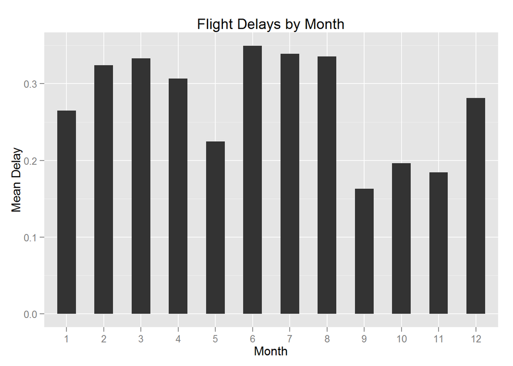

```r
Mgraph <- ggplot(MonthlyDelays)+
  geom_bar(aes(x=Der_Month,y=mean_delays),stat="identity",width=0.5)+
  labs(title="Flight Delays by Month",x="Month",y="Mean Delay")
plot(Mgraph)
```

As we can see there is clearly higher delays in Months *Feb-Apr & Jun-Aug*. That a interesting pattern

#### Average Delays by Hour of Departure

Lets plot delays by Hour

```r
#gather the required data .
##Calculate mean of delays by hour
HourlyDelays<-mutate(data,
                     Der_Hour=str_replace(DepTime, str_sub(DepTime,start=-2),"")
                     )
HourlyDelays <-summarise(group_by(
                                  select(HourlyDelays,Der_Hour,Der_DepDelayed
                                         ),Der_Hour
                                  ),mean_delays=mean(Der_DepDelayed)
                         )

### Convert Hour to int and sort the order
HourlyDelays$Der_Hour <- as.integer(HourlyDelays$Der_Hour)
HourlyDelays<-HourlyDelays[order(HourlyDelays$Der_Hour),]
```

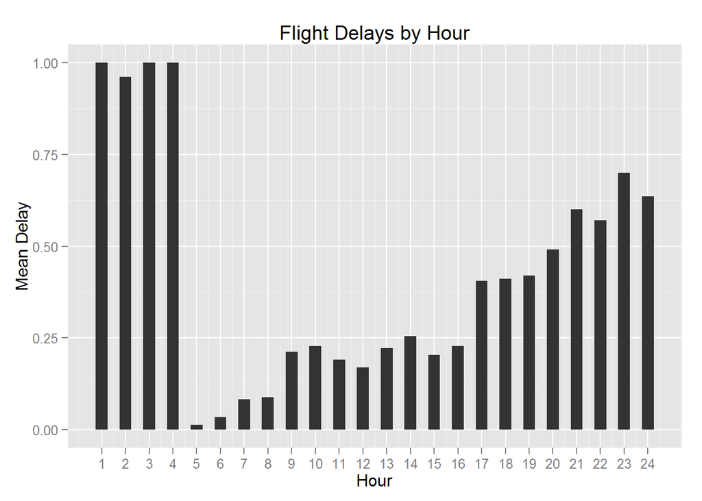

```r
Hgraph <- ggplot(HourlyDelays)+
  geom_bar(aes(x=Der_Hour,y=mean_delays),stat="identity",width=0.5)+
  labs(title="Flight Delays by Hour",x="Hour",y="Mean Delay")+
  scale_x_continuous( breaks=c(1:24))

plot(Hgraph)
```

Again,we can see there is very high delays if the departure times are between *1 AM - 4AM*

#### Average Delays by Carrier

Next lets plot delays by Airline Carrier

```r
#gather the required data .
##Calculate mean of delays by hour
CarrierDelays <-summarise(group_by(
  select(data,UniqueCarrier,Der_DepDelayed),UniqueCarrier
),mean_delays=mean(Der_DepDelayed))
```

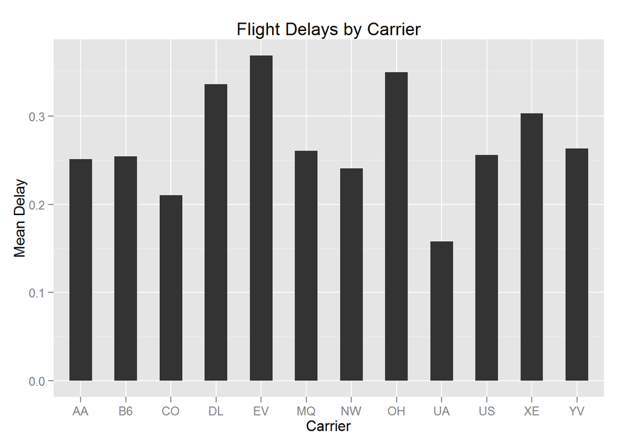

```r
Cgraph <- ggplot(CarrierDelays)+
  geom_bar(aes(x=UniqueCarrier,y=mean_delays),stat="identity",width=0.5)+
  labs(title="Flight Delays by Carrier",x="Carrier",y="Mean Delay")

plot(Cgraph)
```

Again some carriers have mroe delays than others but its not very pronounced pattern.

#### Average Delays by Distance

```r
#gather the required data .
##Calculate mean of delays by distance band
DistanceDelays <- mutate(data,
                         Der_DistanceBand=cut2(data$Distance,g=5))

DistanceDelays <-summarise(group_by(
  select(DistanceDelays,Der_DistanceBand,Der_DepDelayed),Der_DistanceBand
),mean_delays=mean(Der_DepDelayed))
```

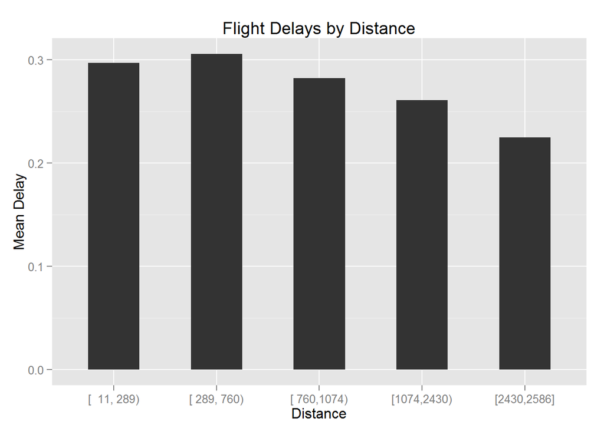

```r
Dgraph <- ggplot(DistanceDelays)+
  geom_bar(aes(x=Der_DistanceBand,y=mean_delays),stat="identity",width=0.5)+
  labs(title="Flight Delays by Distance",x="Distance",y="Mean Delay")

plot(Dgraph)
```

It was interesting to see here that short haul flights from JFK are more delayed than long haul flights.there must be some inherent business process at play here but I dont know this domain well

#### Average Delays by Destination

Finally lets plot delays by Desitnation.Here there are too many destinations so we will clip the plot to have only delays more than 30% of time

```r
#gather the required data .
##Calculate mean of delays by destination
DestDelays <-summarise(group_by(
  select(data,Dest,Der_DepDelayed),Dest
),mean_delays=mean(Der_DepDelayed))

### Focus where MeanDelay is atleast 30%
DestDelays <-filter(DestDelays,mean_delays>=0.30)
```

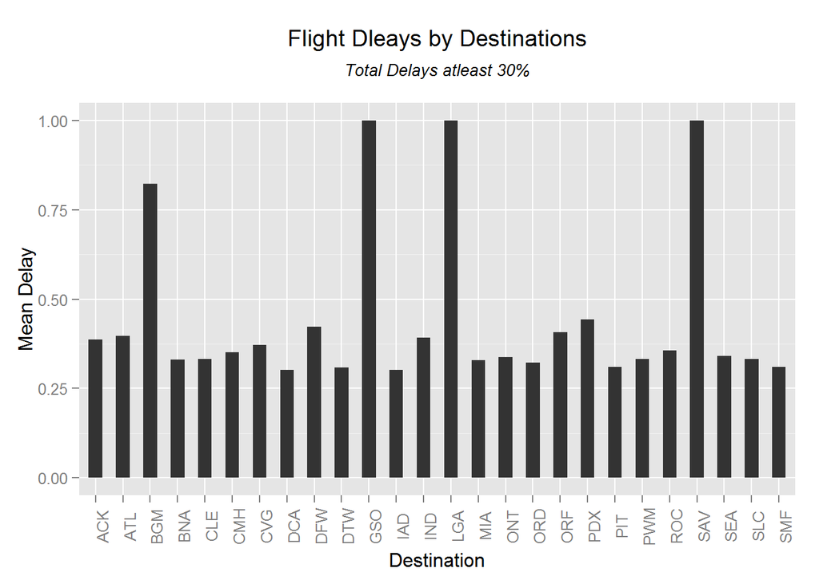

```r
Destgraph <- ggplot(DestDelays )+
  geom_bar(aes(x=Dest,y=mean_delays),stat="identity",width=0.5)+
  labs(title=expression(atop("Flight Dleays by Destinations", atop(italic("Total Delays atleast 30%"), ""))),sub="Destinations where delays are atleast 30%",x="Destination",y="Mean Delay")+
  theme(axis.text.x=element_text(angle=90))

plot(Destgraph)
```

Here again some destinations are more consistently delayed than others.Again, there must be some business process at play here

This concludes our correlation analysis

### Feature Modelling

Now its time to start modelling feature to train a machine learning algorithm

The overview is as follows

**Step 1 -** First we split the data into trian and test sets

**Step 2 -** We create feature matrixes with key columns (based on our above correlation analysis)

**Step 3 -** Then we train a logistic regression model using training matrix.

**Step 4 -** This model is then applied on test feature matrix for cross valdiation

**Step 5 -** Finally we measure metrics on accuracy of our trained algorithm

#### Create Train/Test Sets

```r
# Find subset size
samp_size<-nrow(data)/2

## set the seed to make your partition reproductible
set.seed(123)
train_ind <- sample(seq_len(nrow(data)), size = samp_size,replace=FALSE)

## prepare Training and Test set
traindata <- data[train_ind,]
testdata <- data[-train_ind,]
```

We randomly split the train/test sets into 61134 rows each

#### Create Feature matrixes for train/test sets

```r
trainfeatures<-select(
  mutate(select(traindata,Id,Der_Month,DepTime,UniqueCarrier,Distance,Dest,Der_DepDelayed),
         Month=Der_Month,
         Hour=str_replace(DepTime, str_sub(DepTime,start=-2),""),
         Carrier=UniqueCarrier,
         Destination=Dest,
         IsDelayed=Der_DepDelayed
  )
  ,Id,Month,Hour,Carrier,Distance,Destination,IsDelayed)

# Add Distance Ranges as quartiles
trainfeatures$DistanceRange <- cut2(trainfeatures$Distance,g=5)
```

```r
#Create Test feature matrix
testfeatures<-select(
  mutate(select(testdata,Id,Der_Month,DepTime,UniqueCarrier,Distance,Dest,Der_DepDelayed),
         Month=Der_Month,
         Hour=str_replace(DepTime, str_sub(DepTime,start=-2),""),
         Carrier=UniqueCarrier,
         Destination=Dest,
         IsDelayed=Der_DepDelayed
  )
  ,Id,Month,Hour,Carrier,Distance,Destination,IsDelayed)

# Add Distance Ranges as quartiles
testfeatures$DistanceRange <- cut2(testfeatures$Distance,g=5)
```

Lets see the structure of feature matrix

```r
#structure of training matrix
str(trainfeatures)
```

```
## 'data.frame':    61134 obs. of  8 variables:
##  $ Id           : int  35162 96384 50004 107963 114986 5570 64568 109109 67419 55826 ...
##  $ Month        : Factor w/ 12 levels "1","2","3","4",..: 4 10 5 11 12 1 7 11 7 6 ...
##  $ Hour         : chr  "13" "8" "8" "8" ...
##  $ Carrier      : Factor w/ 20 levels "9E","AA","AQ",..: 5 2 7 5 12 5 2 5 5 5 ...
##  $ Distance     : int  274 1391 1028 1597 340 2446 1597 1428 1069 1989 ...
##  $ Destination  : Factor w/ 310 levels "ABE","ABI","ABQ",..: 241 85 221 272 230 255 272 135 109 273 ...
##  $ IsDelayed    : logi  FALSE TRUE FALSE FALSE FALSE FALSE ...
##  $ DistanceRange: Factor w/ 5 levels "[  11, 289)",..: 1 4 3 4 2 5 4 4 3 4 ...
```

```r
#structure of test matrix
str(trainfeatures)
```

```
## 'data.frame':    61134 obs. of  8 variables:
##  $ Id           : int  35162 96384 50004 107963 114986 5570 64568 109109 67419 55826 ...
##  $ Month        : Factor w/ 12 levels "1","2","3","4",..: 4 10 5 11 12 1 7 11 7 6 ...
##  $ Hour         : chr  "13" "8" "8" "8" ...
##  $ Carrier      : Factor w/ 20 levels "9E","AA","AQ",..: 5 2 7 5 12 5 2 5 5 5 ...
##  $ Distance     : int  274 1391 1028 1597 340 2446 1597 1428 1069 1989 ...
##  $ Destination  : Factor w/ 310 levels "ABE","ABI","ABQ",..: 241 85 221 272 230 255 272 135 109 273 ...
##  $ IsDelayed    : logi  FALSE TRUE FALSE FALSE FALSE FALSE ...
##  $ DistanceRange: Factor w/ 5 levels "[  11, 289)",..: 1 4 3 4 2 5 4 4 3 4 ...
```

#### Build the Model

Now its time for the exciting part, we will have to train logistic regression model with a formula  
`target_variable ~ Indepedent_variable_1 * Indepedent_variable_2 ..Indepedent_variable_n`

`NOTE: Matrix multiplications takes lot of intermediate memory. Here I am using only 2 out of potential 5 variables due to my Laptop memory constraints (8GB Max). If you happen to have a big server ,please add all variables into the formula`

```r
#define formular
formula = "IsDelayed ~ Month * Hour"

#train the algorithm with traindata
glm.logit= glm(formula, family=binomial(logit), data=trainfeatures)
```

#### Predicting with test data

```r
#Predict test set using glm.logit model
predict <- predict(glm.logit,newdata=testfeatures,type="response")
```

Lets first define a function to calculate metrics

```r
# Function to compute Precision, Recall and F1-Measure
get_metrics <- function(predicted, actual) {
  tp = length(which(predicted == TRUE & actual == TRUE))
  tn = length(which(predicted == FALSE & actual == FALSE))
  fp = length(which(predicted == TRUE & actual == FALSE))
  fn = length(which(predicted == FALSE & actual == TRUE))

  precision = tp / (tp+fp)
  recall = tp / (tp+fn)
  F1 = 2*precision*recall / (precision+recall)
  accuracy = (tp+tn) / (tp+tn+fp+fn)

  v = c(precision, recall, F1, accuracy)
  v
}
```

The prediction is in terms of probability .Its usually between 0 and 1.

*Legend: 0=Definetly not delayed,1=Certainly delayed*

So for our case if Probability is >=0.5 we consider it as **Delayed**.

#### Evaluate model

So now that we have predicted values on test data form algorithm,and the actual values from dataset we can cross valdiate the results and compute metrics

```r
metrics = get_metrics(predict>= 0.5,as.logical(testfeatures$IsDelayed))

print(sprintf("Logistic Regression Model1: precision=%0.2f, recall=%0.2f, F1=%0.2f, accuracy=%0.2f",
              metrics[1], metrics[2], metrics[3], metrics[4]))
```

```
## [1] "Logistic Regression Model1: precision=0.62, recall=0.33, F1=0.43, accuracy=0.76"
```

As you can see there is 76% accuracy by using just 2 variables.Had I put through more variables it would take a long time to compute but the accuracy would go up.

### Extension

We are all aware weather makes a major impact of airline operations.So augumenting weather dataset to this data would further improve its results in prediction.